# Independent data analysis

Harsimran Ghai

2026-03-02

Github link: https://github.com/harsimranghai91-eng/CHEP-898-Independent-Analysis-Part-1-.git

# Identify a dataset to work on

I am interested in myocardial infarction and therefore I choose a dataset containing risk factors for myocardial infarction (heart attack) from kaggle website. This dataset is based on chinese population.

The link to the datset is as follows: https://www.kaggle.com/datasets/ankushpanday2/heart-attack-risk-dataset-of-china

# Goals of the analysis

# Statistical Analysis Plan

The stages of analysis are as follows

## Data Wrangling

-Loading the dataset and examine the structure of variables -Checking for missing and duplicate data -Correct the formatting of the data set

## Descriptive Analysis

- Calculating the measure of central tendancy and measure of dispersion for continuous data.
- Calculating frequency and proportion for categorical variables

## Data Visualisation

- Bar Chart
- Box Plots

## Binary Logistic Regression

- Splitting the data into testing (70%) and training data (30%)
- Building a model using the dependent variable that is heart attack (Binary in nature:0/1) and the predictors variables (see below).
- Checking the model performance on the testing data (Cross validation).

## Classifiication Tree

Classification tree model will be built using the below mentioned predictors to predictor heart attack.

Both models will be compared by creating the confusion matrix and calculating the associated measures (Sensitivity, specificity, accuracy, etc.) to select the best model. # Variable Information

## Independent Variables

1. **Age** – Continuous
2. **Blood Pressure** – Continuous
3. **CVD Risk Score** – Continuous
4. **Hypertension** – Binary
5. **Diabetes** – Binary
6. **Obesity** – Binary
7. **Cholesterol** – Categorical (High, Normal, Low)
8. **Air Pollution Exposure** – Categorical (High, Medium, Low)
9. **Physical Activity** – Categorical (High, Medium, Low)
10. **Diet Score** – Categorical (Poor, Moderate, Healthy)
11. **Stress Level** – Categorical (Low, Medium, High)
12. **Alcohol Consumption** – Binary
13. **Family History CVD** – Binary
14. **Healthcare Access** – Categorical (Poor, Moderate, Good)
15. **Rural or Urban** – Binary
16. **Hospital Availability** – Categorical (Low, Medium, High)
17. **TCM Use** – Binary
18. **Employment Status** – Categorical (Employed, Unemployed, Retired)
19. **Education Level** – Categorical (None, Primary, Secondary, Higher)
20. **Income Level** – Categorical (Low, Middle, High)
21. **Chronic Kidney Disease** – Binary
22. **Previous Heart Attack** – Binary

# Data Wrangling

```r
# Loading the data
data<-read.csv("heart_attack_china.csv")
```

```r
# Loading the Packages
library(tidyverse)
library(tidymodels)
```

```r
library(reportRmd)
library(sjPlot)
library(plotly)
library(psych)
library(parallel)
library(finalfit)
library(gtsummary)
library(mlbench)
library(vip)
library(rsample)
library(tune)
library(recipes)
library(yardstick)
library(parsnip)
library(glmnet)
library(themis)
library(corrr)
library(performance)
library(utils)
library(see)
library(forestmodel)
```

# Taking a look into data set

```r
glimpse(data)
```

```
## Rows: 239,266
## Columns: 28
## $ Patient_ID             <int> 1, 2, 3, 4, 5, 6, 7, 8, 9, 10, 11, 12, 13, 14, …
## $ Age                    <int> 55, 66, 69, 45, 39, 76, 37, 88, 54, 47, 62, 83,…
## $ Gender                 <chr> "Male", "Female", "Female", "Female", "Female",…
## $ Smoking_Status         <chr> "Non-Smoker", "Smoker", "Smoker", "Smoker", "Sm…
## $ Hypertension           <chr> "No", "Yes", "No", "No", "No", "No", "No", "Yes…
## $ Diabetes               <chr> "No", "No", "No", "Yes", "No", "No", "No", "No"…
## $ Obesity                <chr> "Yes", "No", "No", "No", "No", "No", "No", "Yes…
## $ Cholesterol_Level      <chr> "Normal", "Low", "Low", "Normal", "Normal", "Lo…
## $ Air_Pollution_Exposure <chr> "High", "Medium", "Medium", "Medium", "Medium",…
## $ Physical_Activity      <chr> "High", "High", "High", "Low", "Medium", "Low",…
## $ Diet_Score             <chr> "Moderate", "Healthy", "Moderate", "Healthy", "…
## $ Stress_Level           <chr> "Low", "Medium", "Low", "Medium", "Low", "Mediu…
## $ Alcohol_Consumption    <chr> "Yes", "No", "No", "Yes", "No", "No", "No", "No…
## $ Family_History_CVD     <chr> "No", "Yes", "No", "No", "No", "Yes", "Yes", "N…
## $ Healthcare_Access      <chr> "Good", "Poor", "Poor", "Poor", "Moderate", "Mo…
## $ Rural_or_Urban         <chr> "Rural", "Urban", "Rural", "Rural", "Urban", "U…
## $ Region                 <chr> "Eastern", "Eastern", "Eastern", "Central", "We…
## $ Province               <chr> "Beijing", "Qinghai", "Henan", "Qinghai", "Guan…
## $ Hospital_Availability  <chr> "Low", "High", "Low", "Medium", "Low", "Low", "…
## $ TCM_Use                <chr> "Yes", "No", "No", "Yes", "No", "Yes", "Yes", "…
## $ Employment_Status      <chr> "Unemployed", "Unemployed", "Unemployed", "Empl…
## $ Education_Level        <chr> "Primary", "Secondary", "Primary", "Primary", "…
## $ Income_Level           <chr> "Low", "Middle", "High", "Low", "Middle", "Midd…
## $ Blood_Pressure         <int> 104, 142, 176, 178, 146, 92, 144, 162, 93, 125,…
## $ Chronic_Kidney_Disease <chr> "Yes", "No", "No", "No", "Yes", "No", "Yes", "N…
## $ Previous_Heart_Attack  <chr> "No", "No", "No", "Yes", "No", "No", "No", "No"…
## $ CVD_Risk_Score         <int> 78, 49, 31, 23, 79, 49, 81, 27, 62, 67, 94, 82,…
## $ Heart_Attack           <chr> "No", "No", "No", "No", "No", "No", "No", "No",…
```

This dataset has a total of 28 variables and a sample size of 239,266

# Checking duplicates

```r
sum(duplicated(data))
```

```
## [1] 0
```

No duplicated observation were observed in this dataset.

# Checking the missing data

```r
any(is.na(data))
```

```
## [1] FALSE
```

No missing data was found in this data set, so we don’t need to do anything for the missing data.

# Checking the structure in the data set

```r
str(data)
```

```
## 'data.frame':    239266 obs. of  28 variables:
##  $ Patient_ID            : int  1 2 3 4 5 6 7 8 9 10 ...
##  $ Age                   : int  55 66 69 45 39 76 37 88 54 47 ...
##  $ Gender                : chr  "Male" "Female" "Female" "Female" ...
##  $ Smoking_Status        : chr  "Non-Smoker" "Smoker" "Smoker" "Smoker" ...
##  $ Hypertension          : chr  "No" "Yes" "No" "No" ...
##  $ Diabetes              : chr  "No" "No" "No" "Yes" ...
##  $ Obesity               : chr  "Yes" "No" "No" "No" ...
##  $ Cholesterol_Level     : chr  "Normal" "Low" "Low" "Normal" ...
##  $ Air_Pollution_Exposure: chr  "High" "Medium" "Medium" "Medium" ...
##  $ Physical_Activity     : chr  "High" "High" "High" "Low" ...
##  $ Diet_Score            : chr  "Moderate" "Healthy" "Moderate" "Healthy" ...
##  $ Stress_Level          : chr  "Low" "Medium" "Low" "Medium" ...
##  $ Alcohol_Consumption   : chr  "Yes" "No" "No" "Yes" ...
##  $ Family_History_CVD    : chr  "No" "Yes" "No" "No" ...
##  $ Healthcare_Access     : chr  "Good" "Poor" "Poor" "Poor" ...
##  $ Rural_or_Urban        : chr  "Rural" "Urban" "Rural" "Rural" ...
##  $ Region                : chr  "Eastern" "Eastern" "Eastern" "Central" ...
##  $ Province              : chr  "Beijing" "Qinghai" "Henan" "Qinghai" ...
##  $ Hospital_Availability : chr  "Low" "High" "Low" "Medium" ...
##  $ TCM_Use               : chr  "Yes" "No" "No" "Yes" ...
##  $ Employment_Status     : chr  "Unemployed" "Unemployed" "Unemployed" "Employed" ...
##  $ Education_Level       : chr  "Primary" "Secondary" "Primary" "Primary" ...
##  $ Income_Level          : chr  "Low" "Middle" "High" "Low" ...
##  $ Blood_Pressure        : int  104 142 176 178 146 92 144 162 93 125 ...
##  $ Chronic_Kidney_Disease: chr  "Yes" "No" "No" "No" ...
##  $ Previous_Heart_Attack : chr  "No" "No" "No" "Yes" ...
##  $ CVD_Risk_Score        : int  78 49 31 23 79 49 81 27 62 67 ...
##  $ Heart_Attack          : chr  "No" "No" "No" "No" ...
```

# Changing the Structure of variables

```r
data <- data%>%mutate(across(c( Gender,
                                Smoking_Status,
                                Hypertension,
                                Diabetes,
                                Obesity,
                                Cholesterol_Level,
                                Air_Pollution_Exposure,
                                Physical_Activity,
                                Diet_Score,
                                Stress_Level,
                                Alcohol_Consumption,
                                Family_History_CVD,
                                Healthcare_Access,
                                Rural_or_Urban,
                                Hospital_Availability,
                                TCM_Use,
                                Employment_Status,
                                Education_Level,
                                Income_Level,
                                Chronic_Kidney_Disease,
                                Previous_Heart_Attack,
                                Heart_Attack

),~ as.factor(.)))
```

# Descriptive Analysis

```r
rm_covsum(
  data = data,
                        covs = c('Age',
                                'Blood_Pressure',
                                'CVD_Risk_Score',
                                'Hypertension',
                                'Diabetes',
                                'Obesity',
                                'Cholesterol_Level',
                                'Air_Pollution_Exposure',
                                'Physical_Activity',
                                'Diet_Score',
                                'Stress_Level',
                                'Alcohol_Consumption',
                                'Family_History_CVD',
                                'Healthcare_Access',
                                'Rural_or_Urban',
                                'Hospital_Availability',
                                'TCM_Use',
                                'Employment_Status',
                                'Education_Level',
                                'Income_Level',
                                'Chronic_Kidney_Disease',
                                'Previous_Heart_Attack',
                                'Heart_Attack')
)
```

|  | n=239266 |
| --- | --- |
| Age |  |
| Mean (sd) | 59.5 (17.3) |
| Median (Min,Max) | 59 (30, 89) |
| Blood Pressure |  |
| Mean (sd) | 134.5 (26.0) |
| Median (Min,Max) | 135 (90, 179) |
| CVD Risk Score |  |
| Mean (sd) | 54.5 (26.0) |
| Median (Min,Max) | 54 (10, 99) |
| Hypertension |  |
| No | 174557 (73) |
| Yes | 64709 (27) |
| Diabetes |  |
| No | 212794 (89) |
| Yes | 26472 (11) |
| Obesity |  |
| No | 167521 (70) |
| Yes | 71745 (30) |
| Cholesterol Level |  |
| High | 79620 (33) |
| Low | 79555 (33) |
| Normal | 80091 (33) |
| Air Pollution Exposure |  |
| High | 48019 (20) |
| Low | 71654 (30) |
| Medium | 119593 (50) |
| Physical Activity |  |
| High | 79250 (33) |
| Low | 80086 (33) |
| Medium | 79930 (33) |
| Diet Score |  |
| Healthy | 79656 (33) |
| Moderate | 79954 (33) |
| Poor | 79656 (33) |
| Stress Level |  |
| High | 79857 (33) |
| Low | 80120 (33) |
| Medium | 79289 (33) |
| Alcohol Consumption |  |
| No | 167156 (70) |
| Yes | 72110 (30) |
| Family History CVD |  |
| No | 179740 (75) |
| Yes | 59526 (25) |
| Healthcare Access |  |
| Good | 79643 (33) |
| Moderate | 79711 (33) |
| Poor | 79912 (33) |
| Rural or Urban |  |
| Rural | 143507 (60) |
| Urban | 95759 (40) |
| Hospital Availability |  |
| High | 79848 (33) |
| Low | 79589 (33) |
| Medium | 79829 (33) |
| TCM Use |  |
| No | 143949 (60) |
| Yes | 95317 (40) |
| Employment Status |  |
| Employed | 79638 (33) |
| Retired | 79872 (33) |
| Unemployed | 79756 (33) |
| Education Level |  |
| Higher | 59942 (25) |
| None | 59617 (25) |
| Primary | 59901 (25) |
| Secondary | 59806 (25) |
| Income Level |  |
| High | 80149 (33) |
| Low | 79797 (33) |
| Middle | 79320 (33) |
| Chronic Kidney Disease |  |
| No | 203597 (85) |
| Yes | 35669 (15) |
| Previous Heart Attack |  |
| No | 215306 (90) |
| Yes | 23960 (10) |
| Heart Attack |  |
| No | 210195 (88) |
| Yes | 29071 (12) |

# Bar Graphs

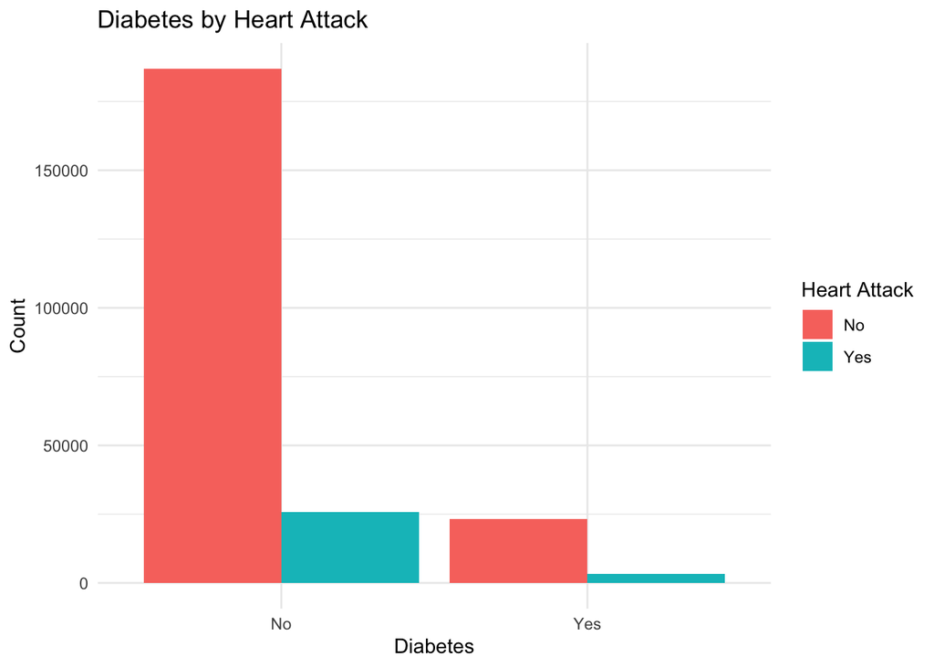

```r
ggplot(data, aes(x = Diabetes, fill = Heart_Attack)) +
  geom_bar(position = "dodge") +
  labs(
    title = "Diabetes by Heart Attack",
    x = "Diabetes",
    y = "Count",
    fill = "Heart Attack"
  ) +
  theme_minimal()
```

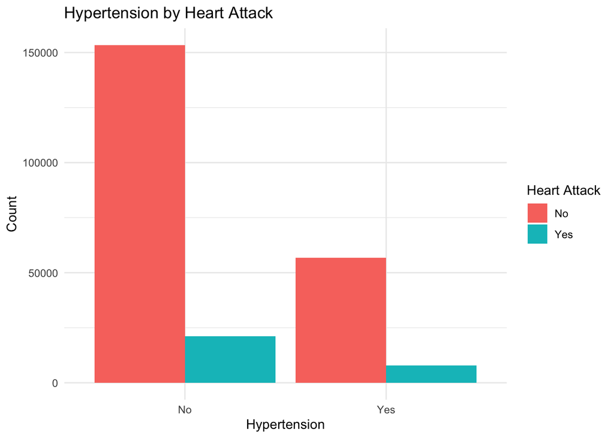

```r
ggplot(data, aes(x =Hypertension , fill = Heart_Attack)) +
  geom_bar(position = "dodge") +
  labs(
    title = "Hypertension by Heart Attack",
    x = "Hypertension",
    y = "Count",
    fill = "Heart Attack"
  ) +
  theme_minimal()
```

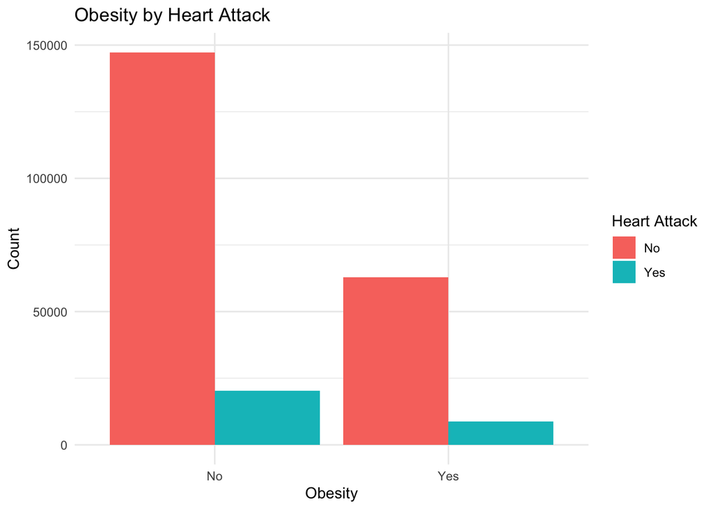

```r
ggplot(data, aes(x =Obesity , fill = Heart_Attack)) +
  geom_bar(position = "dodge") +
  labs(
    title = "Obesity by Heart Attack",
    x = "Obesity",
    y = "Count",
    fill = "Heart Attack"
  ) +
  theme_minimal()
```

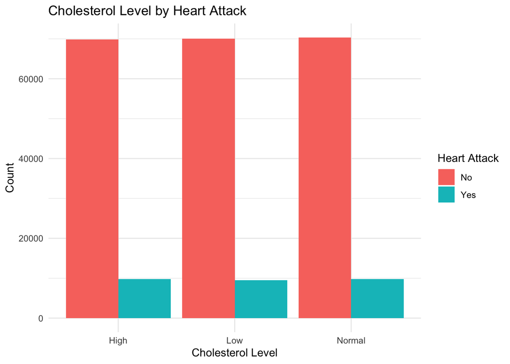

```r
ggplot(data, aes(x =Cholesterol_Level , fill = Heart_Attack)) +
  geom_bar(position = "dodge") +
  labs(
    title = "Cholesterol Level by Heart Attack ",
    x = "Cholesterol Level",
    y = "Count",
    fill = "Heart Attack"
  ) +
  theme_minimal()
```

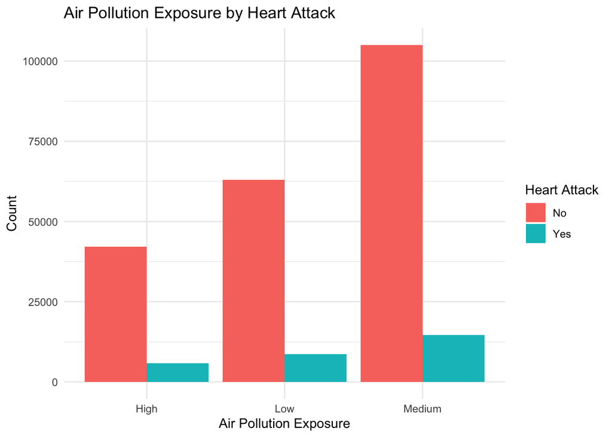

```r
ggplot(data, aes(x = Air_Pollution_Exposure, fill = Heart_Attack)) +
  geom_bar(position = "dodge") +
  labs(
    title = "Air Pollution Exposure by Heart Attack",
    x = "Air Pollution Exposure",
    y = "Count",
    fill = "Heart Attack"
  ) +
  theme_minimal()
```

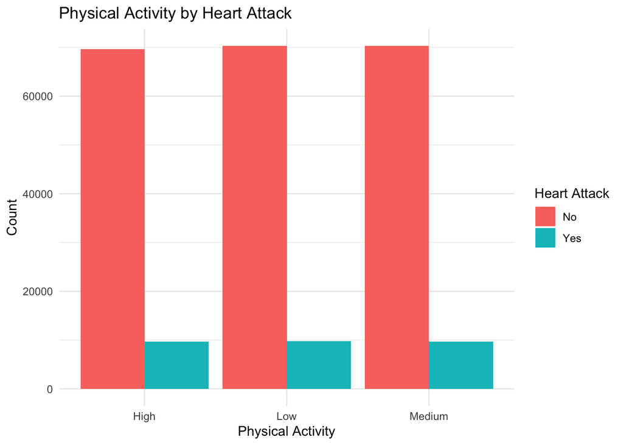

```r
ggplot(data, aes(x = Physical_Activity, fill = Heart_Attack)) +
  geom_bar(position = "dodge") +
  labs(
    title = "Physical Activity by Heart Attack",
    x = "Physical Activity",
    y = "Count",
    fill = "Heart Attack"
  ) +
  theme_minimal()
```

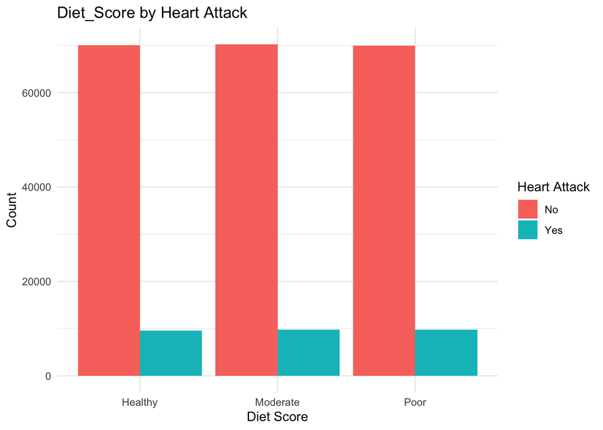

```r
ggplot(data, aes(x = Diet_Score, fill = Heart_Attack)) +
  geom_bar(position = "dodge") +
  labs(
    title = "Diet_Score by Heart Attack",
    x = "Diet Score",
    y = "Count",
    fill = "Heart Attack"
  ) +
  theme_minimal()
```

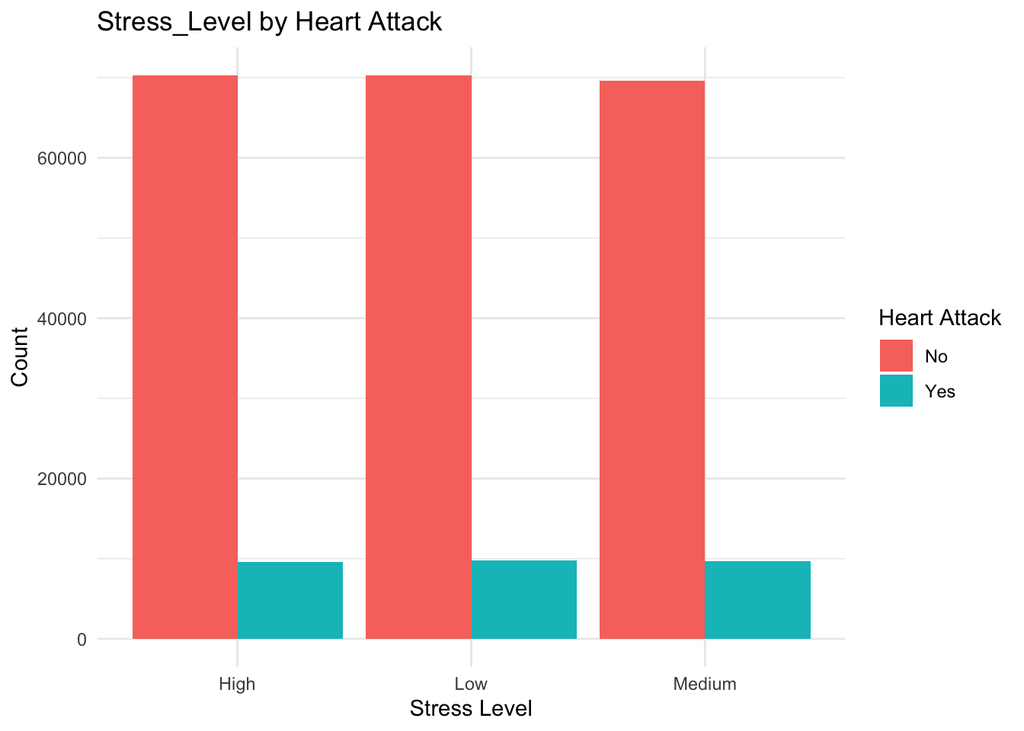

```r
ggplot(data, aes(x = Stress_Level, fill = Heart_Attack)) +
  geom_bar(position = "dodge") +
  labs(
    title = "Stress_Level by Heart Attack",
    x = "Stress Level",
    y = "Count",
    fill = "Heart Attack"
  ) +
  theme_minimal()
```

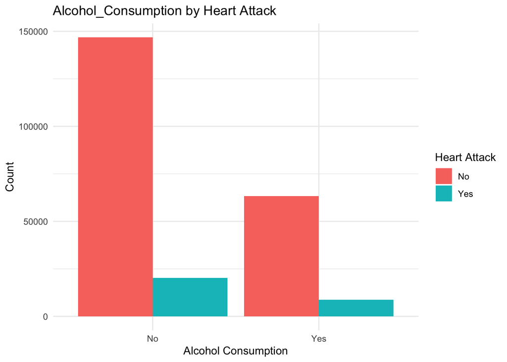

```r
ggplot(data, aes(x = Alcohol_Consumption, fill = Heart_Attack)) +
  geom_bar(position = "dodge") +
  labs(
    title = "Alcohol_Consumption by Heart Attack",
    x = "Alcohol Consumption",
    y = "Count",
    fill = "Heart Attack"
  ) +
  theme_minimal()
```

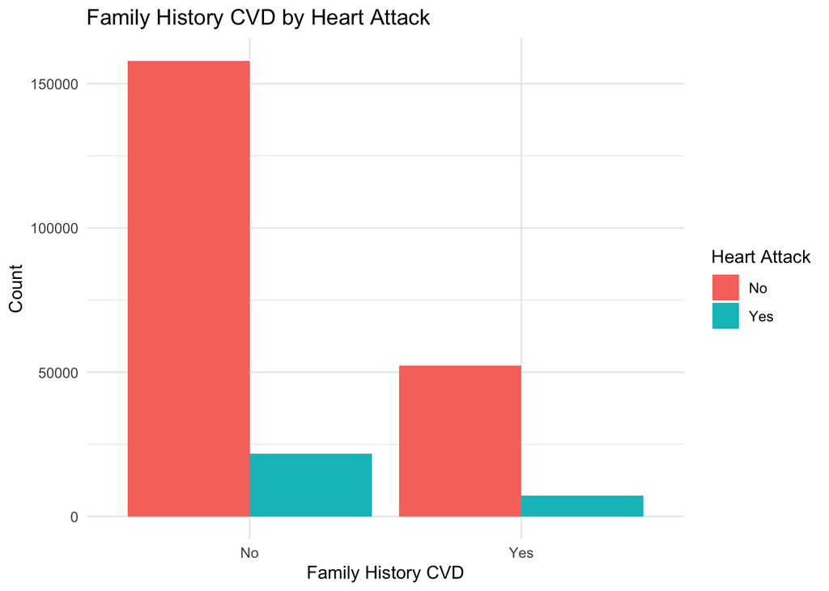

```r
ggplot(data, aes(x = Family_History_CVD, fill = Heart_Attack)) +
  geom_bar(position = "dodge") +
  labs(
    title = "Family History CVD by Heart Attack",
    x = "Family History CVD",
    y = "Count",
    fill = "Heart Attack"
  ) +
  theme_minimal()
```

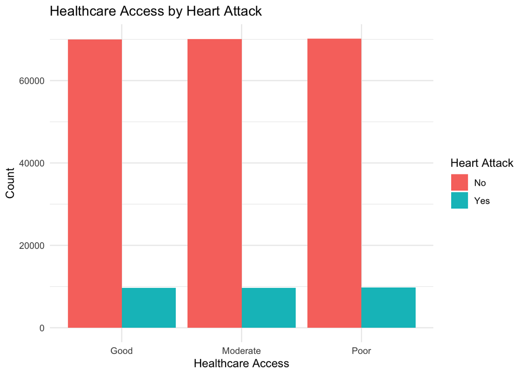

```r
ggplot(data, aes(x = Healthcare_Access, fill = Heart_Attack)) +
  geom_bar(position = "dodge") +
  labs(
    title = "Healthcare Access by Heart Attack",
    x = "Healthcare Access",
    y = "Count",
    fill = "Heart Attack"
  ) +
  theme_minimal()
```

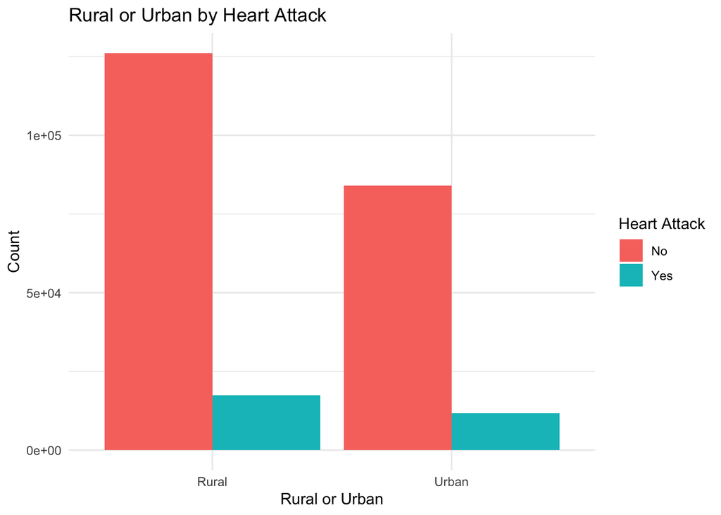

```r
ggplot(data, aes(x = Rural_or_Urban, fill = Heart_Attack)) +
  geom_bar(position = "dodge") +
  labs(
    title = "Rural or Urban by Heart Attack",
    x = "Rural or Urban",
    y = "Count",
    fill = "Heart Attack"
  ) +
  theme_minimal()
```

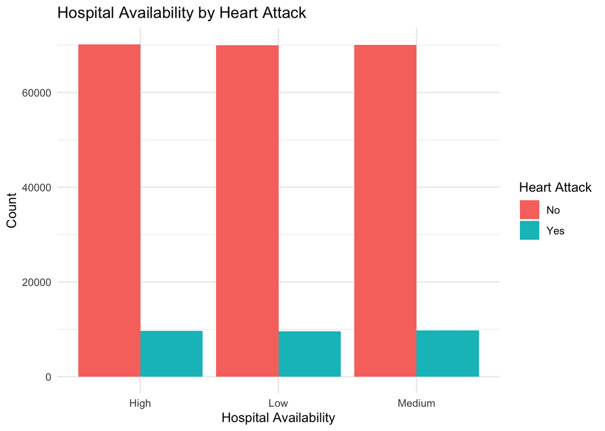

```r
ggplot(data, aes(x = Hospital_Availability, fill = Heart_Attack)) +
  geom_bar(position = "dodge") +
  labs(
    title = "Hospital Availability by Heart Attack",
    x = "Hospital Availability",
    y = "Count",
    fill = "Heart Attack"
  ) +
  theme_minimal()
```

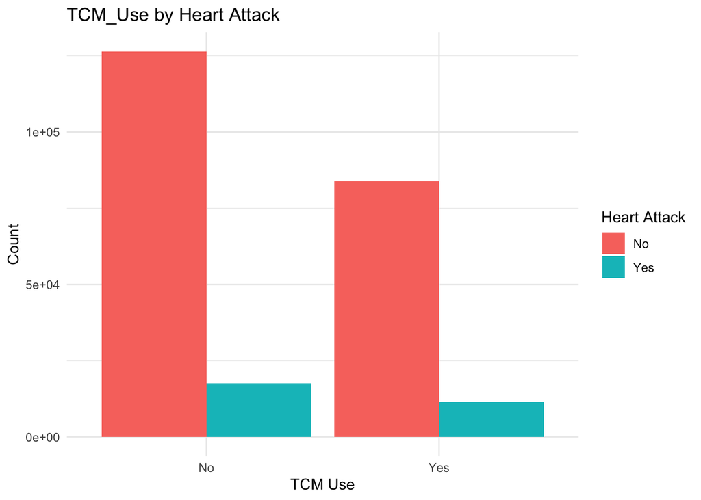

```r
ggplot(data, aes(x = TCM_Use, fill = Heart_Attack)) +
  geom_bar(position = "dodge") +
  labs(
    title = "TCM_Use by Heart Attack",
    x = "TCM Use",
    y = "Count",
    fill = "Heart Attack"
  ) +
  theme_minimal()
```

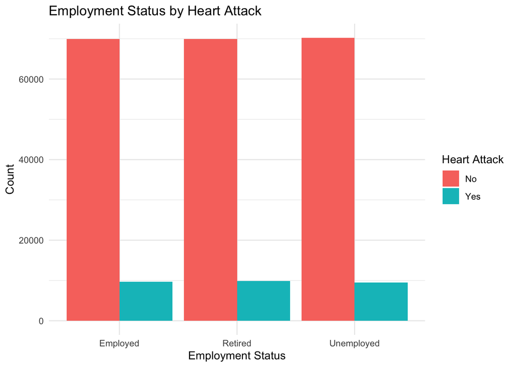

```r
ggplot(data, aes(x = Employment_Status, fill = Heart_Attack)) +
  geom_bar(position = "dodge") +
  labs(
    title = "Employment Status by Heart Attack",
    x = "Employment Status",
    y = "Count",
    fill = "Heart Attack"
  ) +
  theme_minimal()
```

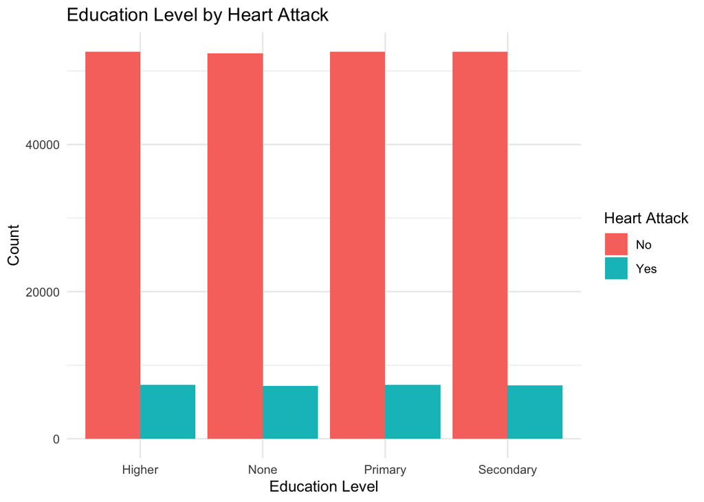

```r
ggplot(data, aes(x = Education_Level, fill = Heart_Attack)) +
  geom_bar(position = "dodge") +
  labs(
    title = "Education Level by Heart Attack",
    x = "Education Level",
    y = "Count",
    fill = "Heart Attack"
  ) +
  theme_minimal()
```

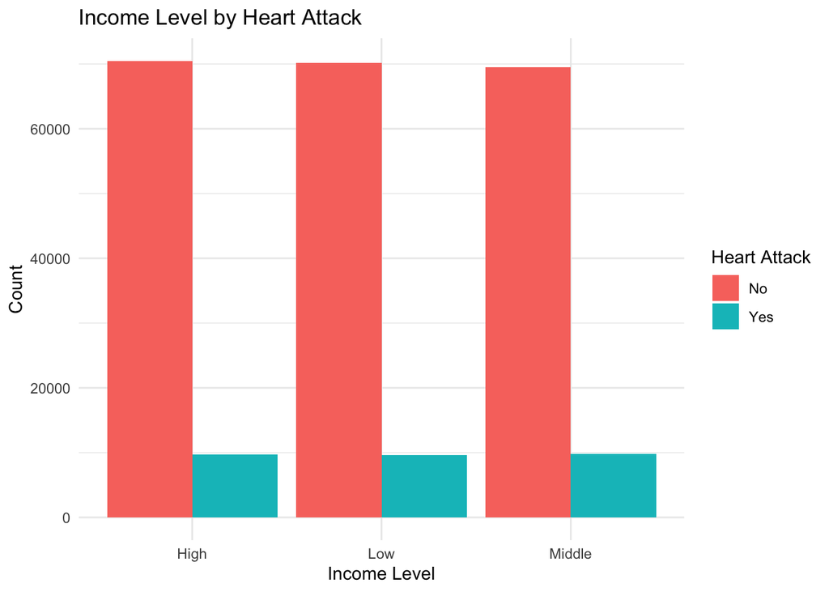

```r
ggplot(data, aes(x = Income_Level, fill = Heart_Attack)) +
  geom_bar(position = "dodge") +
  labs(
    title = "Income Level by Heart Attack",
    x = "Income Level",
    y = "Count",
    fill = "Heart Attack"
  ) +
  theme_minimal()
```

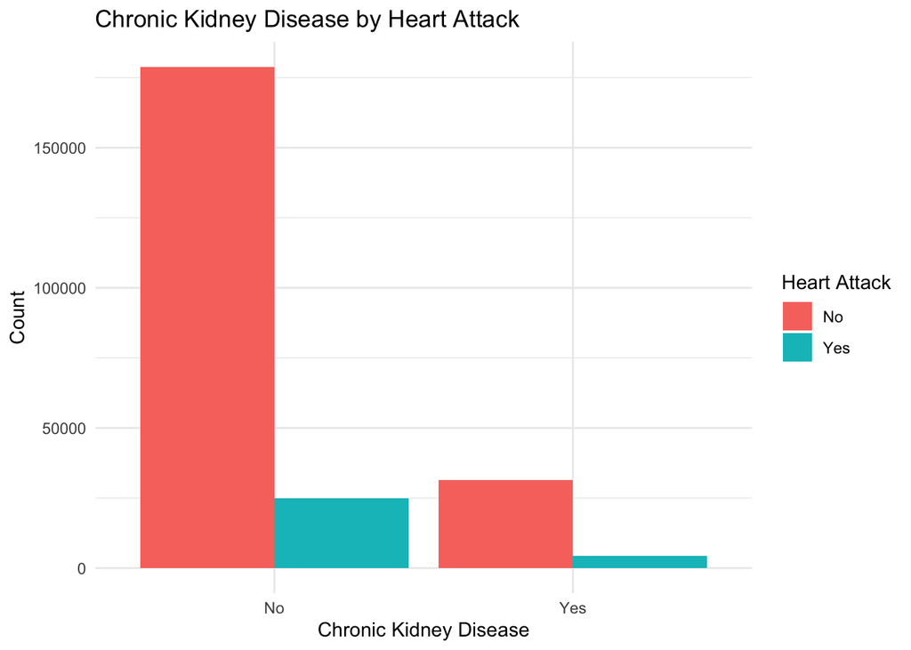

```r
ggplot(data, aes(x = Chronic_Kidney_Disease, fill = Heart_Attack)) +
  geom_bar(position = "dodge") +
  labs(
    title = "Chronic Kidney Disease by Heart Attack",
    x = "Chronic Kidney Disease",
    y = "Count",
    fill = "Heart Attack"
  ) +
  theme_minimal()
```

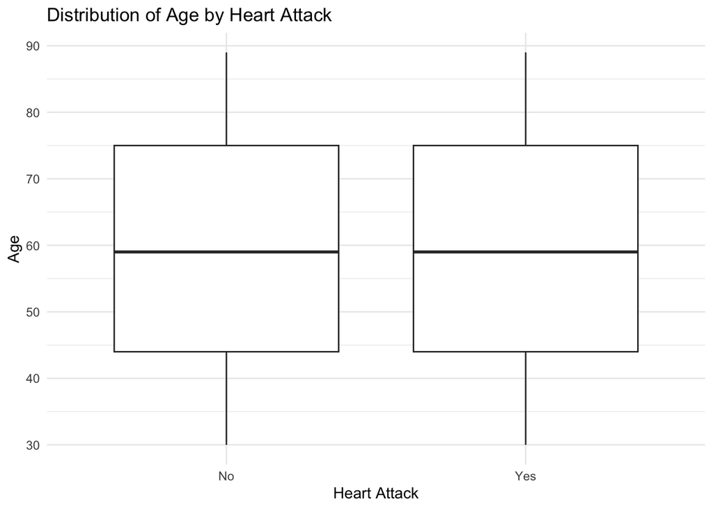

```r
ggplot(data, aes(x = Heart_Attack, y = Age)) +
  geom_boxplot() +
  labs(
    x = "Heart Attack",
    y = "Age",
    title = "Distribution of Age by Heart Attack"
  ) +
  theme_minimal()
```

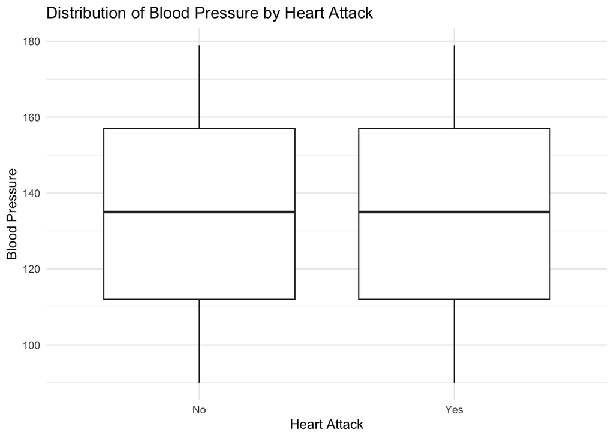

```r
ggplot(data, aes(x = Heart_Attack, y = Blood_Pressure)) +
  geom_boxplot() +
  labs(
    x = "Heart Attack",
    y = "Blood Pressure",
    title = "Distribution of Blood Pressure by Heart Attack"
  ) +
  theme_minimal()
```

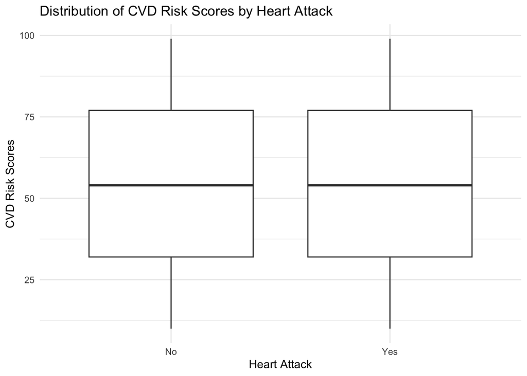

```r
ggplot(data, aes(x = Heart_Attack, y = CVD_Risk_Score)) +
  geom_boxplot() +
  labs(
    x = "Heart Attack",
    y = "CVD Risk Scores",
    title = "Distribution of CVD Risk Scores by Heart Attack"
  ) +
  theme_minimal()
```